# DATA 624 Homework 3

### Exercise 5.11.2

Use the Facebook stock price (data set `gafa_stock`) to do the following:

**a.** Produce a time plot of the series.

We filter the `gafa_stock` data to get the stock of interest, in this cae Facebook:

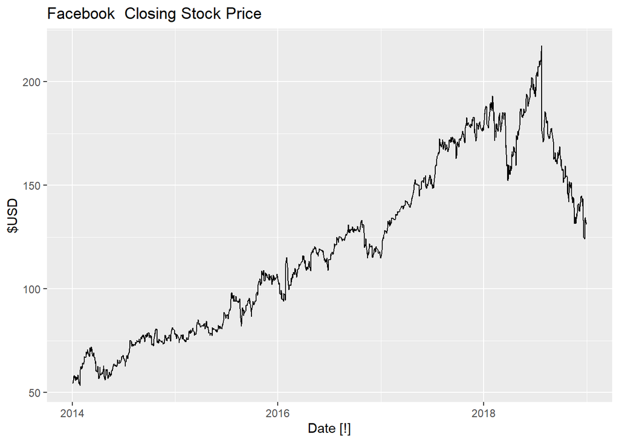

```r
facebook <- gafa_stock %>%
  filter(Symbol=="FB")

autoplot(facebook,Close)+labs(y="$USD", title="Facebook  Closing Stock Price")
```

**b.** Produce forecasts using the drift method and plot them.

I borrowed a code example from the book, which originally produced a forecast for Google, and applied it to the data for Facebook. The code uses data from the year 2015 as the training data for the model and then makes a forecast on data from January 2016.

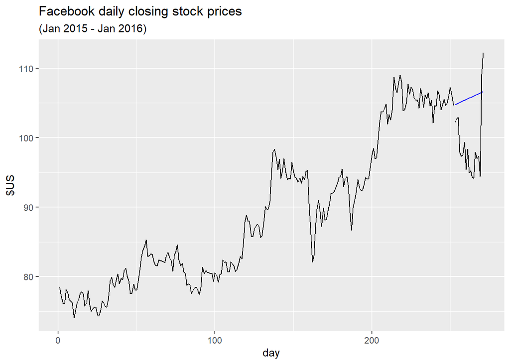

```r
# Re-index based on trading days
facebook_stock <- gafa_stock %>%
  filter(Symbol == "FB", year(Date) >= 2015) %>%
  mutate(day = row_number()) %>%
  update_tsibble(index = day, regular = TRUE)
# Filter the year of interest
facebook_2015 <- facebook_stock %>% filter(year(Date) == 2015)
# Fit the models
facebook_fit <- facebook_2015 %>%
  model(
    Drift = NAIVE(Close ~ drift())
  )
# Produce forecasts for the trading days in January 2016
facebook_jan_2016 <- facebook_stock %>%
  filter(yearmonth(Date) == yearmonth("2016 Jan"))
facebook_fc <- facebook_fit %>%
  forecast(new_data = facebook_jan_2016)
# Plot the forecasts
facebook_fc %>%
  autoplot(facebook_2015, level = NULL) +
  autolayer(facebook_jan_2016, Close, colour = "black") +
  labs(y = "$US",
       title = "Facebook daily closing stock prices",
       subtitle = "(Jan 2015 - Jan 2016)") +
  guides(colour = guide_legend(title = "Forecast"))
```

**c.** Show that the forecasts are identical to extending the line drawn between the first and last observations.

As we can see below, our previous forecast extends a line drawn between the first and last observation.

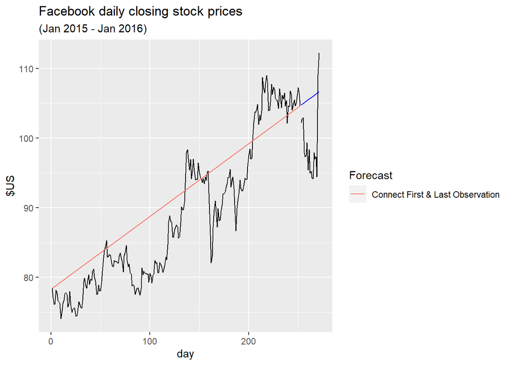

```r
facebook_fc %>%
  autoplot(facebook_2015, level = NULL) +
  autolayer(facebook_jan_2016, Close, colour = "black") +
  geom_segment(aes(x = 1, y = 78.45, xend = 252, yend = 104.66, colour = "Connect First & Last Observation"), data = facebook_2015) +
  labs(y = "$US",
       title = "Facebook daily closing stock prices",
       subtitle = "(Jan 2015 - Jan 2016)") +
  guides(colour = guide_legend(title = "Forecast"))
```

**d.** Try using some of the other benchmark functions to forecast the same data set. Which do you think is best? Why?

I think that the best model for this data is the naive method as these type of data such as the price of stock follow a random walk.

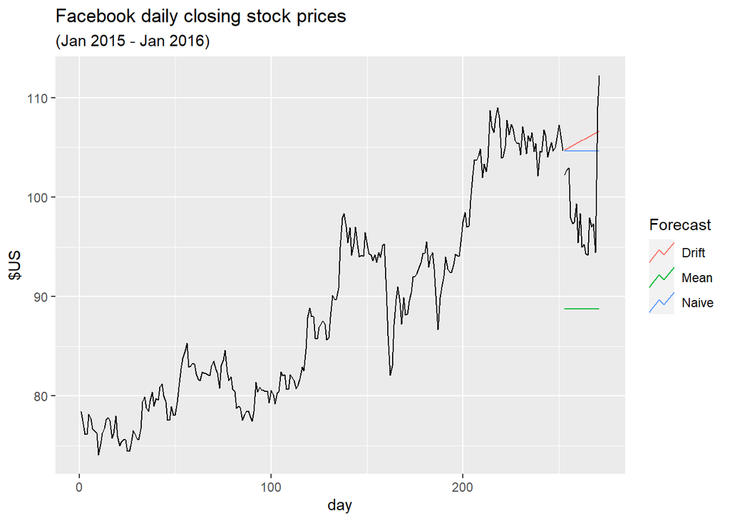

```r
# Fit the other models
facebook_fit2 <- facebook_2015 %>%
  model(
    Mean = MEAN(Close),
    Naive = NAIVE(Close),
    Drift = NAIVE(Close ~ drift())
  )
# Produce forecasts for the trading days in January 2016
facebook_jan_2016 <- facebook_stock %>%
  filter(yearmonth(Date) == yearmonth("2016 Jan"))
facebook_fc2 <- facebook_fit2 %>%
  forecast(new_data = facebook_jan_2016)
# Plot the forecasts
facebook_fc2 %>%
  autoplot(facebook_2015, level = NULL) +
  autolayer(facebook_jan_2016, Close, colour = "black") +
  labs(y = "$US",
       title = "Facebook daily closing stock prices",
       subtitle = "(Jan 2015 - Jan 2016)") +
  guides(colour = guide_legend(title = "Forecast"))
```